# PROGRAMACIÓN Y DATA SCIENCE CON R - INTERMEDIO

### ggplot2

Vamos a corregir los nombres y darle otros colores

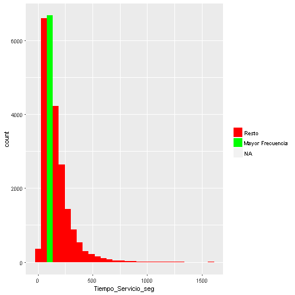

```r
ggplot(data_banco, aes(x = Tiempo_Servicio_seg)) +
  geom_histogram(aes(y    = ..count..,
                     fill = cut(..count.., c(0, sort(..count.., TRUE)[1:2]))
                                  )) +
  scale_fill_manual("", values = c("red", "green"), labels=c("Resto","Mayor Frecuencia"))
```

### ggplot2

Título, labels, temas.

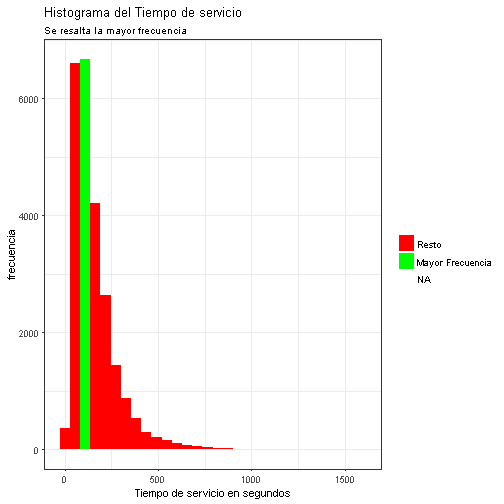

```r
ggplot(data_banco, aes(x = Tiempo_Servicio_seg)) +
  geom_histogram(aes(y    = ..count..,
                     fill = cut(..count.., c(0, sort(..count.., TRUE)[1:2]))
                                  )) +
  scale_fill_manual("", values = c("red", "green"), labels=c("Resto","Mayor Frecuencia")) +
  labs(title= "Histograma del Tiempo de servicio", subtitle = "Se resalta la mayor frecuencia",
       x= "Tiempo de servicio en segundos", y="frecuencia") +
  theme_bw()
```

### ggplot2

Siendo mucho más detallista

```r
ggplot(data_banco, aes(x = Tiempo_Servicio_seg)) +
  geom_histogram(aes(y    = ..count..,
                     fill = cut(..count.., c(0, sort(..count.., TRUE)[1:2]))
                                  )) +
  scale_fill_manual("", values = c("red", "green"), labels=c("Resto","Mayor Frecuencia")) +
  labs(title= "Histograma del Tiempo de servicio", subtitle = "Se resalta la mayor frecuencia",
       x= "Tiempo de servicio en segundos", y="frecuencia") +
theme_bw() +
        theme(axis.line = element_line(size=1, colour = "black"),
              panel.grid.major = element_line(colour = "#d3d3d3"),
              panel.grid.minor = element_blank(),
              panel.border = element_blank(), panel.background = element_blank(),
              plot.title = element_text(size = 14, family = "Tahoma", face = "bold"),
              text=element_text(family="Tahoma"),
              axis.text.x=element_text(colour="black", size = 9),
              axis.text.y=element_text(colour="black", size = 9))
```

### ggplot2

Siendo mucho más detallista

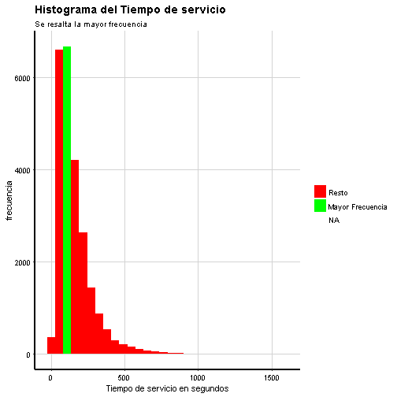

### ggplot2

Ahora vamos a realizar un boxplot

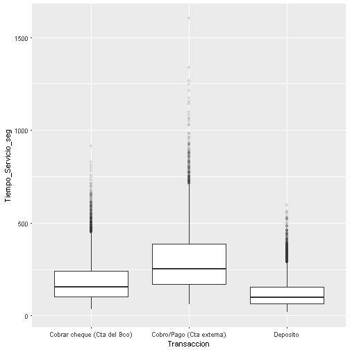

```r
ggplot(data_banco, aes(x= Transaccion, y = Tiempo_Servicio_seg)) +
  geom_boxplot( outlier.alpha = 0.1)
```

### ggplot2

Graficando los puntos encima del boxplot

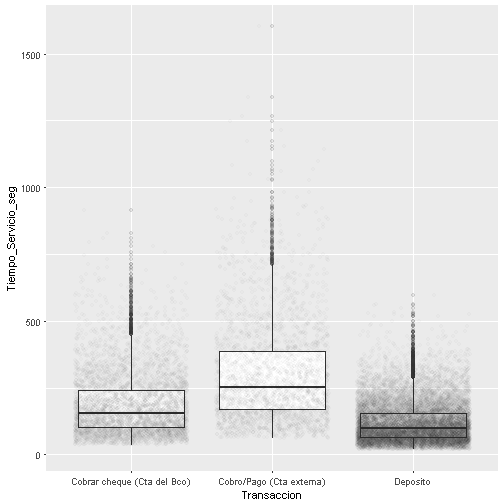

```r
ggplot(data_banco, aes(x= Transaccion, y = Tiempo_Servicio_seg)) +
  geom_boxplot(outlier.alpha = 0.1)+ geom_jitter(alpha= 0.01)
```

### ggplot2

Para comparar mediana con rango intercuartil

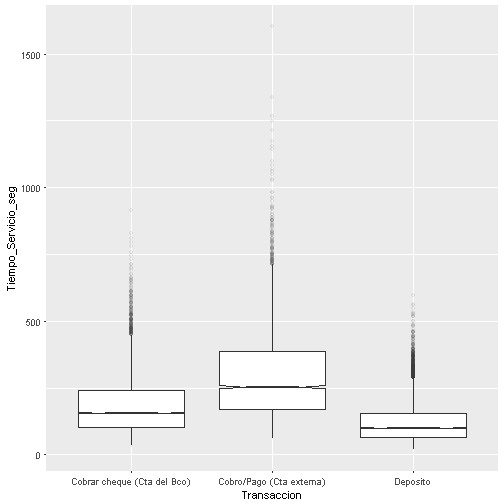

```r
ggplot(data_banco, aes(x= Transaccion, y = Tiempo_Servicio_seg)) +
  geom_boxplot(outlier.alpha = 0.05, notch = TRUE)
```

### ggplot2

Agregar la media

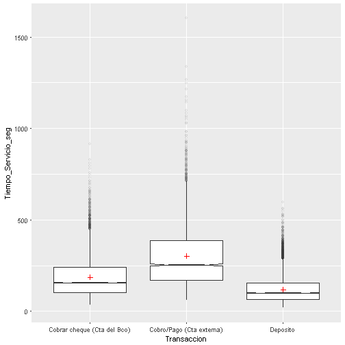

```r
ggplot(data_banco, aes(x= Transaccion, y = Tiempo_Servicio_seg)) +
  geom_boxplot(outlier.alpha = 0.05, notch = TRUE)+
  stat_summary(fun.y=mean, geom="point", shape=3, size=2, color= "red")
```

### ggplot2

boxplot horizontal

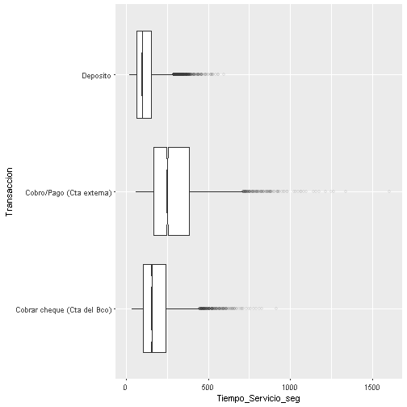

```r
ggplot(data_banco, aes(x= Transaccion, y = Tiempo_Servicio_seg)) +
  geom_boxplot(outlier.alpha = 0.05, notch = TRUE) +
  coord_flip()
```

### ggplot2

boxplot horizontal y mapeando a fill el uso del nuevo sistema

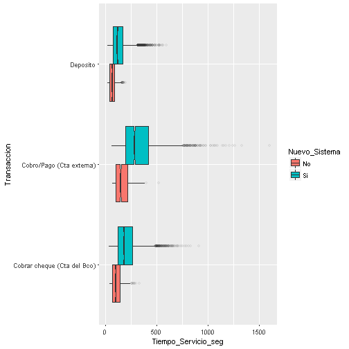

```r
ggplot(data_banco, aes(x= Transaccion, y = Tiempo_Servicio_seg, fill= Nuevo_Sistema )) +
  geom_boxplot(outlier.alpha = 0.05, notch = TRUE) +
  coord_flip()
```

### ggplot2

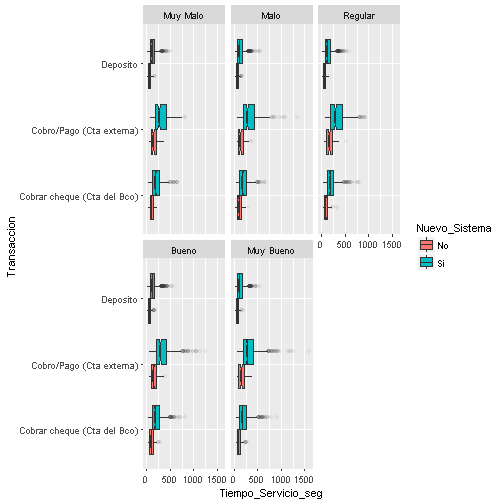

```r
ggplot(data_banco, aes(x= Transaccion, y = Tiempo_Servicio_seg, fill= Nuevo_Sistema )) +
  geom_boxplot(outlier.alpha = 0.05, notch = TRUE) +
  coord_flip() +
  facet_wrap("Satisfaccion")
```

### ggplot2

Reemplazando boxplot por geom_violin

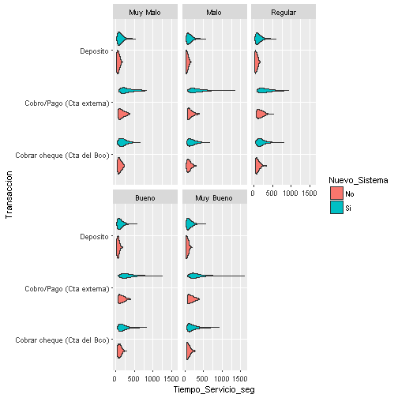

```r
ggplot(data_banco, aes(x= Transaccion, y = Tiempo_Servicio_seg, fill= Nuevo_Sistema )) +
  geom_violin() +
  coord_flip() +
  facet_wrap("Satisfaccion")
```

### ggplot2

Boxplot para dos variables cuantitativas

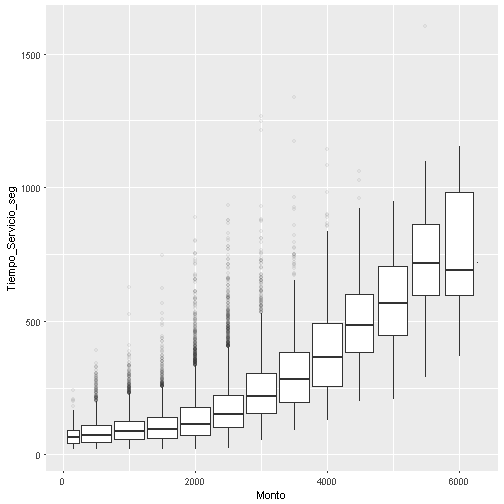

```r
ggplot(data_banco, aes(x= Monto, y = Tiempo_Servicio_seg)) +
  geom_boxplot( aes(group= cut_width(Monto, 500)), outlier.alpha = 0.05)
```

### ggplot2

Agregamos un facet por Nuevo Sistema

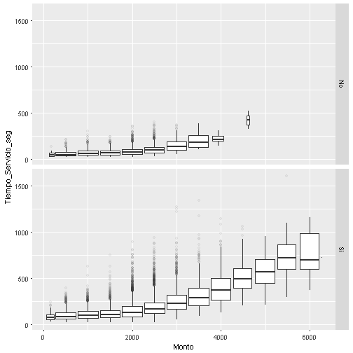

```r
ggplot(data_banco, aes(x= Monto, y = Tiempo_Servicio_seg)) +
  geom_boxplot( aes(group= cut_width(Monto, 500)), outlier.alpha = 0.05) +
  facet_grid(Nuevo_Sistema~.)
```

### ggplot2

Agregamos un facet por Nuevo Sistema y Satisfaccion

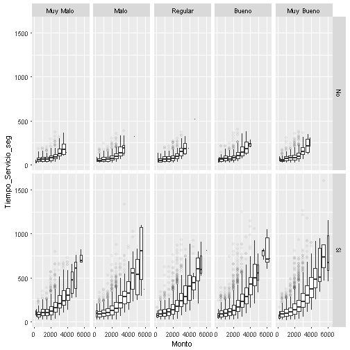

```r
ggplot(data_banco, aes(x= Monto, y = Tiempo_Servicio_seg)) +
  geom_boxplot( aes(group= cut_width(Monto, 500)), outlier.alpha = 0.05) +
  facet_grid(Nuevo_Sistema~Satisfaccion)
```

### ggplot2

Graficar la relación entre dos variables cuantitativas con diagramas de dispersión

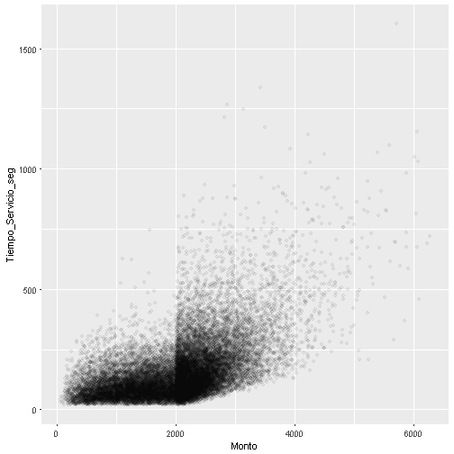

```r
ggplot(data_banco, aes(x= Monto, y = Tiempo_Servicio_seg)) +
  geom_point( alpha=0.05)
```

### ggplot2

Podemos mapear el color a la variable Transaccion

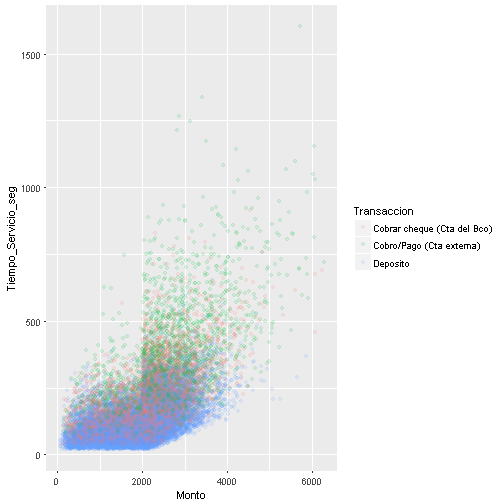

```r
ggplot(data_banco, aes(x= Monto, y = Tiempo_Servicio_seg)) +
  geom_point( aes(color= Transaccion), alpha=0.1)
```

### ggplot2

Podemos mapear el color a la variable Transaccion

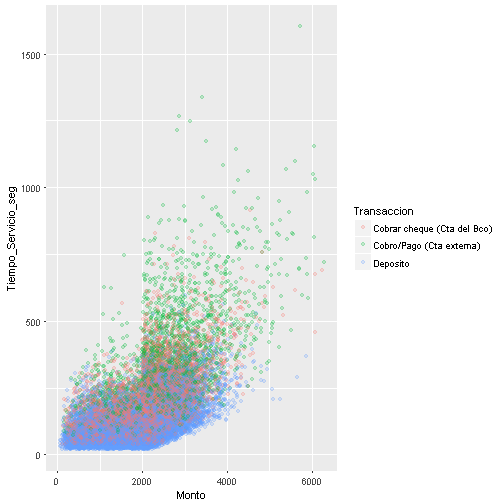

```r
ggplot(data_banco, aes(x= Monto, y = Tiempo_Servicio_seg)) +
  geom_point( aes(color= Transaccion), alpha=0.2)
```

### ggplot2

En un gráfico de dispersión podemos mapear la forma del punto

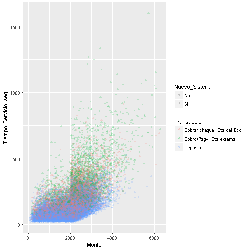

```r
ggplot(data_banco, aes(x= Monto, y = Tiempo_Servicio_seg)) +
  geom_point( aes(color= Transaccion, shape= Nuevo_Sistema), alpha=0.2)
```

### ggplot2

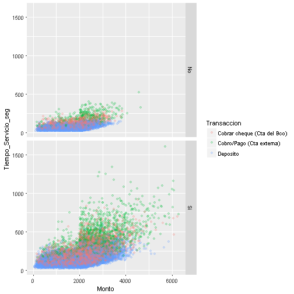

```r
ggplot(data_banco, aes(x= Monto, y = Tiempo_Servicio_seg)) +
  geom_point( aes(color= Transaccion), alpha=0.2) +
  facet_grid(Nuevo_Sistema~.)
```

### ggplot2

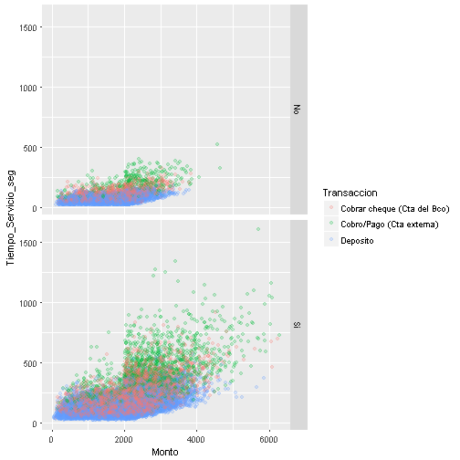

```r
ggplot(data_banco, aes(x= Monto, y = Tiempo_Servicio_seg)) +
  geom_point( aes(color= Transaccion), alpha=0.2) +
  facet_grid(Nuevo_Sistema~.)
```

### ggplot2

En base a la cantidad de información que se tiene se modifica geom_point a geom_hex

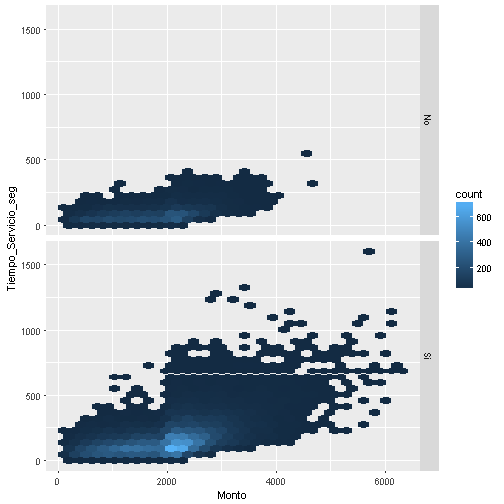

```r
ggplot(data_banco, aes(x= Monto, y = Tiempo_Servicio_seg)) +
  geom_hex() +
  facet_grid(Nuevo_Sistema~.)
```

### ggplot2

geom_hex

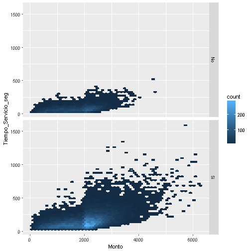

```r
ggplot(data_banco, aes(x= Monto, y = Tiempo_Servicio_seg)) +
  geom_hex(bins = 50) +
  facet_grid(Nuevo_Sistema~.)
```

### ggplot2

geom_hex

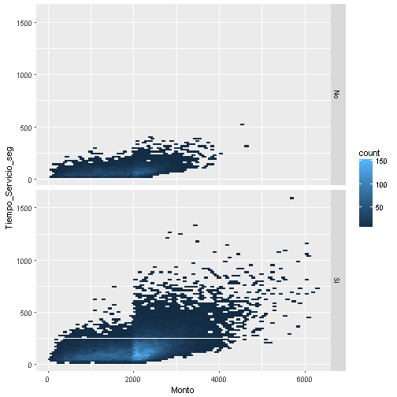

```r
ggplot(data_banco, aes(x= Monto, y = Tiempo_Servicio_seg)) +
  geom_hex(binwidth = c(100, 20)) +
  facet_grid(Nuevo_Sistema~.)
```

### ggplot2

geom_hex

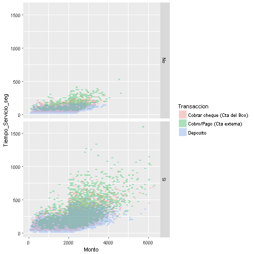

```r
ggplot(data_banco, aes(x= Monto, y = Tiempo_Servicio_seg, fill= Transaccion)) +
  geom_hex(binwidth = c(100, 20), alpha= 0.3) +
  facet_grid(Nuevo_Sistema~.)
```

### ggplot2

geom_hex

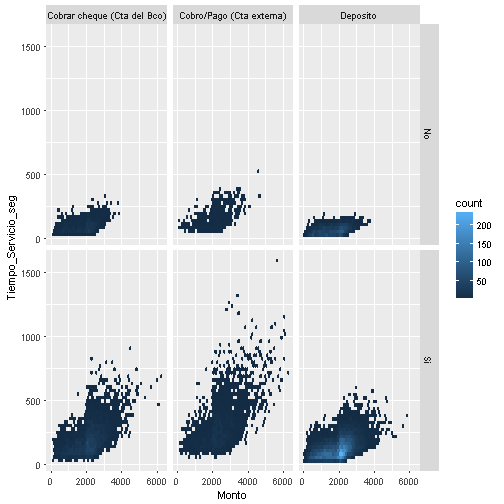

```r
ggplot(data_banco, aes(x= Monto, y = Tiempo_Servicio_seg)) +
  geom_hex(bins = 50) +
  facet_grid(Nuevo_Sistema~Transaccion)
```

### ggplot2

Agregamos un layer con densidad en 2D

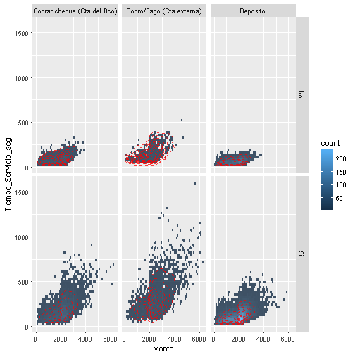

```r
ggplot(data_banco, aes(x= Monto, y = Tiempo_Servicio_seg)) +
  geom_hex(bins = 50, alpha= 0.8) +
  geom_density_2d(alpha= 0.75, color= "red", linetype="dashed") +
  facet_grid(Nuevo_Sistema~Transaccion)
```

### ggplot2

Agregamos un layer con densidad en 2D

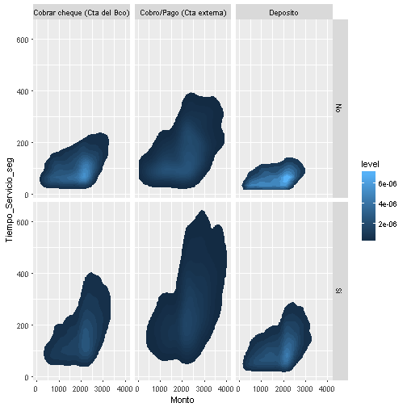

```r
ggplot(data_banco, aes(x= Monto, y = Tiempo_Servicio_seg)) +
  stat_density_2d(aes(fill = ..level..), geom="polygon")+
  facet_grid(Nuevo_Sistema~Transaccion)
```

### Data a usar

```r
set.seed(123)
df_1 <- data.frame(
  ALMACEN= rep(c("Mall del Sol", "Riocentro"), each= 6),
  PRODUCTO= paste("Prod", LETTERS[1:6], sep="_"),
  PERIODO= rep(seq.Date(from=as.Date("2015-01-01"), to=as.Date("2017-06-01"), by="month"), each=12),
  VTA= runif(n = 360, min = 1000, max= 7000),
  MARGEN= rnorm(n = 360, mean = 30, sd= 6)/100,
  PPTO= runif(n = 360, min = 1000, max= 7000),
  stringsAsFactors = FALSE
)
df_1 %<>% mutate(VTA_COSTO=VTA*(1-MARGEN))
df_1 <- tbl_df(df_1)
```

### ggplot2

Gráfico de linea de la venta. En este caso da error por la repetiión de los periodos

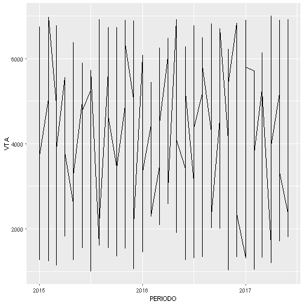

```r
ggplot(df_1, aes(x= PERIODO, y = VTA)) +
  geom_line()
```

### ggplot2

Gráfico de linea de la venta, como tenemos la venta por varios grupos, usamos stat_summary y le declaramos como opción **geom=“line”**

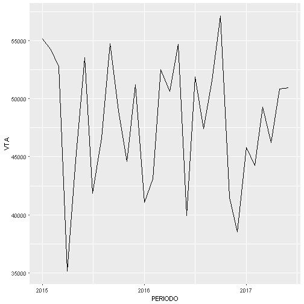

```r
ggplot(df_1, aes(x= PERIODO, y = VTA)) +
  stat_summary(fun.y = sum, geom= "line")
```

### ggplot2

Ahora, podríamos usar también geom_line pero mapeando el color al Producto y haciendo un condicionamiento por almacén

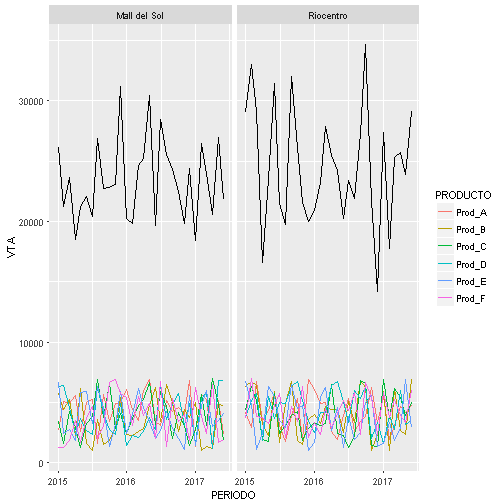

```r
ggplot(df_1, aes(x= PERIODO, y = VTA)) +
  geom_line( aes(color= PRODUCTO)) +
  stat_summary(fun.y = sum, geom= "line") +
  facet_grid(~ALMACEN)
```

### ggplot2

O viceversa

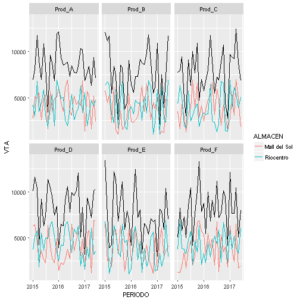

```r
ggplot(df_1, aes(x= PERIODO, y = VTA)) +
  geom_line( aes(color= ALMACEN)) +
  stat_summary(fun.y = sum, geom= "line") +
  facet_wrap(~PRODUCTO)
```

### ggplot2

O bien podemos usar dplyr antes de graficar

```r
df_1 %>%
  group_by(ALMACEN, PERIODO) %>%
  summarise(
    VTA= sum(VTA, na.rm= TRUE),
    PPTO= sum(PPTO, na.rm= TRUE),
  ) %>%
ggplot(., aes(x= PERIODO, y = VTA)) +
  geom_line( aes(color= ALMACEN)) +
  stat_summary(fun.y = sum, geom= "line")
```

### ggplot2

O bien podemos usar dplyr antes de graficar

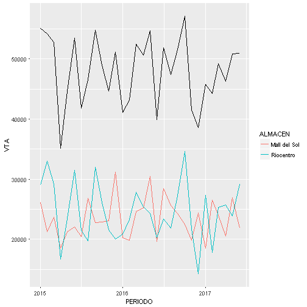

### ggplot2

Y si quiero comparar año vs año el comportamiento mensual?

```r
df_1 %>%
  mutate(
    ANIO= year(PERIODO),
    MES= month(PERIODO)
    ) %>%
  group_by(ALMACEN, ANIO, MES) %>%
  summarise(
    VTA= sum(VTA, na.rm= TRUE),
    PPTO= sum(PPTO, na.rm= TRUE),
  ) %>%
ggplot(., aes(x= MES, y = VTA)) +
  geom_line( aes(color= as.factor(ANIO)), lwd=1) +
  facet_grid(~ALMACEN) +
  scale_color_manual(values=c("darkgray", "blue", "black"))
```

### ggplot2

Y si quiero comparar año vs año el comportamiento mensual?

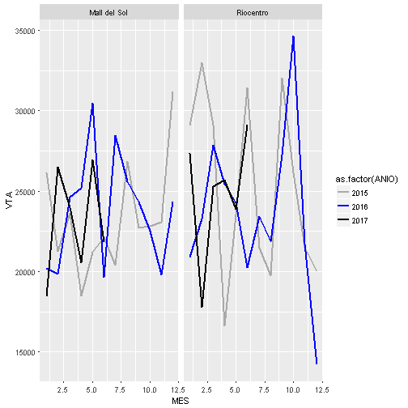

### ggplot2

Y si quiero comparar año vs año el comportamiento mensual?

```r
df_1 %>%
  mutate(
    ANIO= year(PERIODO),
    MES= month(PERIODO)
    ) %>%
  group_by(ALMACEN, ANIO, MES) %>%
  summarise(
    VTA= sum(VTA, na.rm= TRUE),
    PPTO= sum(PPTO, na.rm= TRUE),
  ) %>%
ggplot(., aes(x= MES, y = VTA)) +
  geom_line( aes(color= as.factor(ANIO), linetype= ALMACEN), lwd=1) +
  scale_color_manual(values=c("darkgray", "blue", "black"))
```

### ggplot2

Y si quiero comparar año vs año el comportamiento mensual?

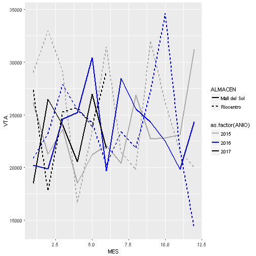

### ggplot2

Explorar gráficamente el nivel de satisfacción en función de la sucursal del Banco.

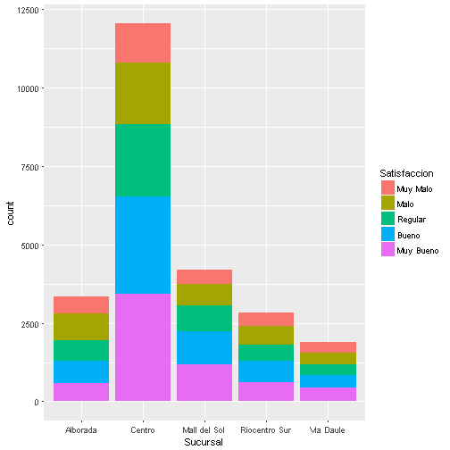

```r
## Grafico de barras de Sucursal vs Satisfaccion
ggplot(data = data_banco, aes(x= Sucursal, fill= Satisfaccion)) +
  geom_bar( )
```

### ggplot2

Explorar gráficamente el nivel de satisfacción en función de la sucursal del Banco.

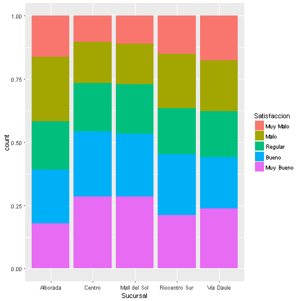

```r
## Grafico de barras de Sucursal vs Satisfaccion
ggplot(data = data_banco, aes(x= Sucursal, fill= Satisfaccion)) +
  geom_bar( position = "fill" )
```

### ggplot2

Explorar gráficamente el nivel de satisfacción en función de la sucursal del Banco.

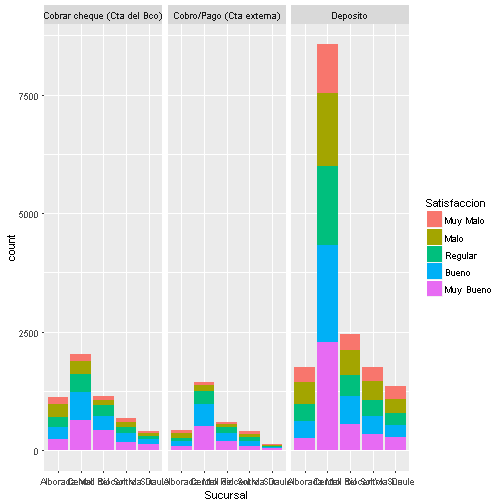

```r
## Grafico de barras de Sucursal vs Satisfaccion
ggplot(data = data_banco, aes(x= Sucursal, fill= Satisfaccion)) +
  geom_bar( ) +
  facet_wrap("Transaccion")
```

### ggplot2

Ejercicio: Llegar a este gráfico

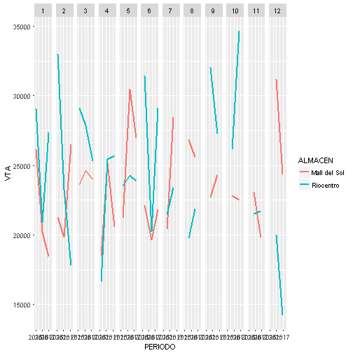